# Risk Factor Analysis

## Outcome Variable

**Outcome Variable:** pers_wast

## Predictor Variables

**Intervention Variable:** birthlen

**Adjustment Set:**

- arm
- sex
- W_mage
- meducyrs
- feducyrs
- vagbrth
- single
- brthmon
- W_parity
- delta_W_mage
- delta_meducyrs
- delta_feducyrs
- delta_vagbrth
- delta_single
- delta_brthmon
- delta_W_parity

## Stratifying Variables

The analysis was stratified on these variable(s):

- agecat
- studyid
- country

## Data Summary

| agecat | studyid | country | birthlen | pers_wast | n_cell | n |
| --- | --- | --- | --- | --- | --- | --- |
| 0-24 months | ki0047075b-MAL-ED | BANGLADESH | >=50 cm | 0 | 36 | 218 |
| 0-24 months | ki0047075b-MAL-ED | BANGLADESH | >=50 cm | 1 | 3 | 218 |
| 0-24 months | ki0047075b-MAL-ED | BANGLADESH | <48 cm | 0 | 95 | 218 |
| 0-24 months | ki0047075b-MAL-ED | BANGLADESH | <48 cm | 1 | 7 | 218 |
| 0-24 months | ki0047075b-MAL-ED | BANGLADESH | [48-50) cm | 0 | 75 | 218 |
| 0-24 months | ki0047075b-MAL-ED | BANGLADESH | [48-50) cm | 1 | 2 | 218 |
| 0-24 months | ki0047075b-MAL-ED | BRAZIL | >=50 cm | 0 | 29 | 62 |
| 0-24 months | ki0047075b-MAL-ED | BRAZIL | >=50 cm | 1 | 0 | 62 |
| 0-24 months | ki0047075b-MAL-ED | BRAZIL | <48 cm | 0 | 17 | 62 |
| 0-24 months | ki0047075b-MAL-ED | BRAZIL | <48 cm | 1 | 0 | 62 |
| 0-24 months | ki0047075b-MAL-ED | BRAZIL | [48-50) cm | 0 | 15 | 62 |
| 0-24 months | ki0047075b-MAL-ED | BRAZIL | [48-50) cm | 1 | 1 | 62 |
| 0-24 months | ki0047075b-MAL-ED | INDIA | >=50 cm | 0 | 8 | 42 |
| 0-24 months | ki0047075b-MAL-ED | INDIA | >=50 cm | 1 | 0 | 42 |
| 0-24 months | ki0047075b-MAL-ED | INDIA | <48 cm | 0 | 19 | 42 |
| 0-24 months | ki0047075b-MAL-ED | INDIA | <48 cm | 1 | 0 | 42 |
| 0-24 months | ki0047075b-MAL-ED | INDIA | [48-50) cm | 0 | 13 | 42 |
| 0-24 months | ki0047075b-MAL-ED | INDIA | [48-50) cm | 1 | 2 | 42 |
| 0-24 months | ki0047075b-MAL-ED | NEPAL | >=50 cm | 0 | 7 | 27 |
| 0-24 months | ki0047075b-MAL-ED | NEPAL | >=50 cm | 1 | 1 | 27 |
| 0-24 months | ki0047075b-MAL-ED | NEPAL | <48 cm | 0 | 12 | 27 |
| 0-24 months | ki0047075b-MAL-ED | NEPAL | <48 cm | 1 | 0 | 27 |
| 0-24 months | ki0047075b-MAL-ED | NEPAL | [48-50) cm | 0 | 7 | 27 |
| 0-24 months | ki0047075b-MAL-ED | NEPAL | [48-50) cm | 1 | 0 | 27 |
| 0-24 months | ki0047075b-MAL-ED | PERU | >=50 cm | 0 | 49 | 220 |
| 0-24 months | ki0047075b-MAL-ED | PERU | >=50 cm | 1 | 0 | 220 |
| 0-24 months | ki0047075b-MAL-ED | PERU | <48 cm | 0 | 83 | 220 |
| 0-24 months | ki0047075b-MAL-ED | PERU | <48 cm | 1 | 1 | 220 |
| 0-24 months | ki0047075b-MAL-ED | PERU | [48-50) cm | 0 | 87 | 220 |
| 0-24 months | ki0047075b-MAL-ED | PERU | [48-50) cm | 1 | 0 | 220 |

[output cut: 414 more lines]

The following strata were considered:

- agecat: 0-24 months, studyid: ki0047075b-MAL-ED, country: BANGLADESH
- agecat: 0-24 months, studyid: ki0047075b-MAL-ED, country: BRAZIL
- agecat: 0-24 months, studyid: ki0047075b-MAL-ED, country: INDIA
- agecat: 0-24 months, studyid: ki0047075b-MAL-ED, country: NEPAL
- agecat: 0-24 months, studyid: ki0047075b-MAL-ED, country: PERU
- agecat: 0-24 months, studyid: ki0047075b-MAL-ED, country: SOUTH AFRICA
- agecat: 0-24 months, studyid: ki0047075b-MAL-ED, country: TANZANIA, UNITED REPUBLIC OF
- agecat: 0-24 months, studyid: ki1000108-CMC-V-BCS-2002, country: INDIA
- agecat: 0-24 months, studyid: ki1000108-IRC, country: INDIA
- agecat: 0-24 months, studyid: ki1000109-EE, country: PAKISTAN
- agecat: 0-24 months, studyid: ki1000109-ResPak, country: PAKISTAN
- agecat: 0-24 months, studyid: ki1000304b-SAS-CompFeed, country: INDIA
- agecat: 0-24 months, studyid: ki1017093-NIH-Birth, country: BANGLADESH
- agecat: 0-24 months, studyid: ki1017093b-PROVIDE, country: BANGLADESH
- agecat: 0-24 months, studyid: ki1017093c-NIH-Crypto, country: BANGLADESH
- agecat: 0-24 months, studyid: ki1101329-Keneba, country: GAMBIA
- agecat: 0-24 months, studyid: ki1113344-GMS-Nepal, country: NEPAL
- agecat: 0-24 months, studyid: ki1114097-CMIN, country: BANGLADESH
- agecat: 0-24 months, studyid: ki1114097-CONTENT, country: PERU
- agecat: 0-24 months, studyid: ki1119695-PROBIT, country: BELARUS
- agecat: 0-24 months, studyid: ki1126311-ZVITAMBO, country: ZIMBABWE
- agecat: 0-24 months, studyid: ki1135781-COHORTS, country: GUATEMALA
- agecat: 0-24 months, studyid: ki1135781-COHORTS, country: INDIA
- agecat: 0-24 months, studyid: ki1135781-COHORTS, country: PHILIPPINES
- agecat: 0-24 months, studyid: kiGH5241-JiVitA-3, country: BANGLADESH
- agecat: 0-24 months, studyid: kiGH5241-JiVitA-4, country: BANGLADESH
- agecat: 0-6 months, studyid: ki0047075b-MAL-ED, country: BANGLADESH
- agecat: 0-6 months, studyid: ki0047075b-MAL-ED, country: BRAZIL
- agecat: 0-6 months, studyid: ki0047075b-MAL-ED, country: INDIA
- agecat: 0-6 months, studyid: ki0047075b-MAL-ED, country: NEPAL
- agecat: 0-6 months, studyid: ki0047075b-MAL-ED, country: PERU
- agecat: 0-6 months, studyid: ki0047075b-MAL-ED, country: SOUTH AFRICA
- agecat: 0-6 months, studyid: ki0047075b-MAL-ED, country: TANZANIA, UNITED REPUBLIC OF
- agecat: 0-6 months, studyid: ki1000108-CMC-V-BCS-2002, country: INDIA
- agecat: 0-6 months, studyid: ki1000108-IRC, country: INDIA
- agecat: 0-6 months, studyid: ki1000109-EE, country: PAKISTAN
- agecat: 0-6 months, studyid: ki1000109-ResPak, country: PAKISTAN
- agecat: 0-6 months, studyid: ki1017093-NIH-Birth, country: BANGLADESH
- agecat: 0-6 months, studyid: ki1017093b-PROVIDE, country: BANGLADESH
- agecat: 0-6 months, studyid: ki1017093c-NIH-Crypto, country: BANGLADESH
- agecat: 0-6 months, studyid: ki1101329-Keneba, country: GAMBIA
- agecat: 0-6 months, studyid: ki1113344-GMS-Nepal, country: NEPAL
- agecat: 0-6 months, studyid: ki1114097-CMIN, country: BANGLADESH
- agecat: 0-6 months, studyid: ki1114097-CONTENT, country: PERU
- agecat: 0-6 months, studyid: ki1119695-PROBIT, country: BELARUS
- agecat: 0-6 months, studyid: ki1126311-ZVITAMBO, country: ZIMBABWE
- agecat: 0-6 months, studyid: ki1135781-COHORTS, country: PHILIPPINES
- agecat: 0-6 months, studyid: kiGH5241-JiVitA-3, country: BANGLADESH
- agecat: 6-24 months, studyid: ki0047075b-MAL-ED, country: BANGLADESH
- agecat: 6-24 months, studyid: ki0047075b-MAL-ED, country: BRAZIL
- agecat: 6-24 months, studyid: ki0047075b-MAL-ED, country: INDIA
- agecat: 6-24 months, studyid: ki0047075b-MAL-ED, country: NEPAL
- agecat: 6-24 months, studyid: ki0047075b-MAL-ED, country: PERU
- agecat: 6-24 months, studyid: ki0047075b-MAL-ED, country: SOUTH AFRICA
- agecat: 6-24 months, studyid: ki0047075b-MAL-ED, country: TANZANIA, UNITED REPUBLIC OF
- agecat: 6-24 months, studyid: ki1000108-CMC-V-BCS-2002, country: INDIA
- agecat: 6-24 months, studyid: ki1000108-IRC, country: INDIA
- agecat: 6-24 months, studyid: ki1000109-EE, country: PAKISTAN
- agecat: 6-24 months, studyid: ki1000109-ResPak, country: PAKISTAN
- agecat: 6-24 months, studyid: ki1000304b-SAS-CompFeed, country: INDIA
- agecat: 6-24 months, studyid: ki1017093-NIH-Birth, country: BANGLADESH
- agecat: 6-24 months, studyid: ki1017093b-PROVIDE, country: BANGLADESH
- agecat: 6-24 months, studyid: ki1017093c-NIH-Crypto, country: BANGLADESH
- agecat: 6-24 months, studyid: ki1101329-Keneba, country: GAMBIA
- agecat: 6-24 months, studyid: ki1113344-GMS-Nepal, country: NEPAL
- agecat: 6-24 months, studyid: ki1114097-CMIN, country: BANGLADESH
- agecat: 6-24 months, studyid: ki1114097-CONTENT, country: PERU
- agecat: 6-24 months, studyid: ki1119695-PROBIT, country: BELARUS
- agecat: 6-24 months, studyid: ki1126311-ZVITAMBO, country: ZIMBABWE
- agecat: 6-24 months, studyid: ki1135781-COHORTS, country: GUATEMALA
- agecat: 6-24 months, studyid: ki1135781-COHORTS, country: INDIA
- agecat: 6-24 months, studyid: ki1135781-COHORTS, country: PHILIPPINES
- agecat: 6-24 months, studyid: kiGH5241-JiVitA-3, country: BANGLADESH
- agecat: 6-24 months, studyid: kiGH5241-JiVitA-4, country: BANGLADESH

### Dropped Strata

Some strata were dropped due to rare outcomes:

- agecat: 0-24 months, studyid: ki0047075b-MAL-ED, country: BANGLADESH
- agecat: 0-24 months, studyid: ki0047075b-MAL-ED, country: BRAZIL
- agecat: 0-24 months, studyid: ki0047075b-MAL-ED, country: INDIA
- agecat: 0-24 months, studyid: ki0047075b-MAL-ED, country: NEPAL
- agecat: 0-24 months, studyid: ki0047075b-MAL-ED, country: PERU
- agecat: 0-24 months, studyid: ki0047075b-MAL-ED, country: SOUTH AFRICA
- agecat: 0-24 months, studyid: ki0047075b-MAL-ED, country: TANZANIA, UNITED REPUBLIC OF
- agecat: 0-24 months, studyid: ki1000108-CMC-V-BCS-2002, country: INDIA
- agecat: 0-24 months, studyid: ki1000109-EE, country: PAKISTAN
- agecat: 0-24 months, studyid: ki1000109-ResPak, country: PAKISTAN
- agecat: 0-24 months, studyid: ki1017093b-PROVIDE, country: BANGLADESH
- agecat: 0-24 months, studyid: ki1017093c-NIH-Crypto, country: BANGLADESH
- agecat: 0-24 months, studyid: ki1114097-CMIN, country: BANGLADESH
- agecat: 0-24 months, studyid: ki1114097-CONTENT, country: PERU
- agecat: 0-24 months, studyid: ki1119695-PROBIT, country: BELARUS
- agecat: 0-6 months, studyid: ki0047075b-MAL-ED, country: BANGLADESH
- agecat: 0-6 months, studyid: ki0047075b-MAL-ED, country: BRAZIL
- agecat: 0-6 months, studyid: ki0047075b-MAL-ED, country: INDIA
- agecat: 0-6 months, studyid: ki0047075b-MAL-ED, country: NEPAL
- agecat: 0-6 months, studyid: ki0047075b-MAL-ED, country: PERU
- agecat: 0-6 months, studyid: ki0047075b-MAL-ED, country: SOUTH AFRICA
- agecat: 0-6 months, studyid: ki0047075b-MAL-ED, country: TANZANIA, UNITED REPUBLIC OF
- agecat: 0-6 months, studyid: ki1000108-CMC-V-BCS-2002, country: INDIA
- agecat: 0-6 months, studyid: ki1000109-EE, country: PAKISTAN
- agecat: 0-6 months, studyid: ki1000109-ResPak, country: PAKISTAN
- agecat: 0-6 months, studyid: ki1017093-NIH-Birth, country: BANGLADESH
- agecat: 0-6 months, studyid: ki1017093b-PROVIDE, country: BANGLADESH
- agecat: 0-6 months, studyid: ki1017093c-NIH-Crypto, country: BANGLADESH
- agecat: 0-6 months, studyid: ki1114097-CMIN, country: BANGLADESH
- agecat: 0-6 months, studyid: ki1114097-CONTENT, country: PERU
- agecat: 0-6 months, studyid: ki1119695-PROBIT, country: BELARUS
- agecat: 0-6 months, studyid: ki1126311-ZVITAMBO, country: ZIMBABWE
- agecat: 0-6 months, studyid: kiGH5241-JiVitA-3, country: BANGLADESH
- agecat: 6-24 months, studyid: ki0047075b-MAL-ED, country: BANGLADESH
- agecat: 6-24 months, studyid: ki0047075b-MAL-ED, country: BRAZIL
- agecat: 6-24 months, studyid: ki0047075b-MAL-ED, country: INDIA
- agecat: 6-24 months, studyid: ki0047075b-MAL-ED, country: NEPAL
- agecat: 6-24 months, studyid: ki0047075b-MAL-ED, country: PERU
- agecat: 6-24 months, studyid: ki0047075b-MAL-ED, country: SOUTH AFRICA
- agecat: 6-24 months, studyid: ki0047075b-MAL-ED, country: TANZANIA, UNITED REPUBLIC OF
- agecat: 6-24 months, studyid: ki1000108-CMC-V-BCS-2002, country: INDIA
- agecat: 6-24 months, studyid: ki1000109-EE, country: PAKISTAN
- agecat: 6-24 months, studyid: ki1000109-ResPak, country: PAKISTAN
- agecat: 6-24 months, studyid: ki1017093b-PROVIDE, country: BANGLADESH
- agecat: 6-24 months, studyid: ki1017093c-NIH-Crypto, country: BANGLADESH
- agecat: 6-24 months, studyid: ki1114097-CMIN, country: BANGLADESH
- agecat: 6-24 months, studyid: ki1114097-CONTENT, country: PERU
- agecat: 6-24 months, studyid: ki1119695-PROBIT, country: BELARUS

## Methods Detail

We’re interested in the causal parameters $E[Y_a]$ for all values of $a \in \mathcal{A}$. These parameters represent the mean outcome if, possibly contrary to fact, we intervened to set all units to have $A=a$. Under the randomization and positivity assumptions, these are identified by the statistical parameters $\psi_a=E_W[E_{Y|A,W}(Y|A=a,W)]$. In addition, we’re interested in the mean of $Y$, $E[Y]$ under no intervention (the observed mean). We will estimate these parameters by using SuperLearner to fit the relevant likelihood factors – $E_{Y|A,W}(Y|A=a,W)$ and $p(A=a|W)$, and then updating our likelihood fit using a joint TMLE.

For unadjusted analyses ($W=\{\}$), initial likelihoods were estimated using Lrnr_glm to estimate the simple $E(Y|A)$ and Lrnr_mean to estimate $p(A)$. For adjusted analyses, a small library containing Lrnr_glmnet, Lrnr_xgboost, and Lrnr_mean was used.

Having estimated these parameters, we will then use the delta method to estimate relative risks and attributable risks relative to a prespecified baseline level of $A$.

# Results Detail

## Results Plots

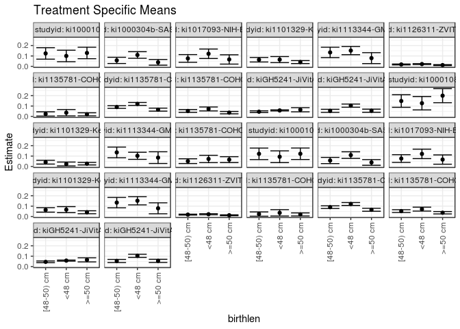

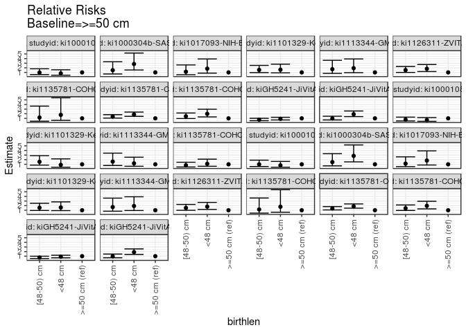

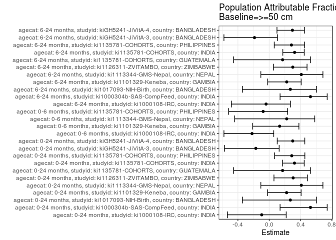

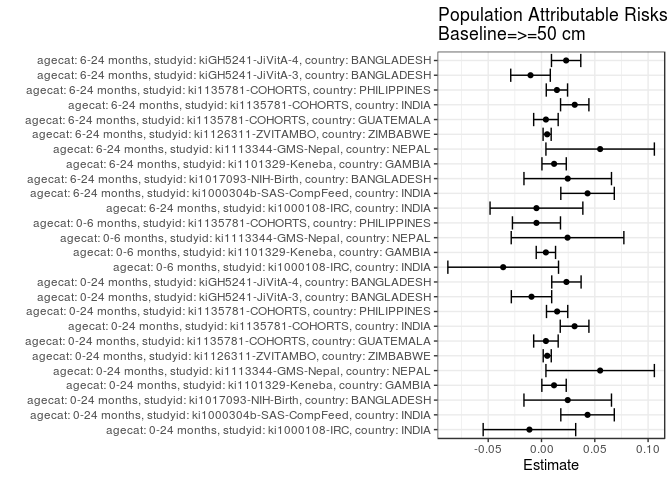

## Results Table

### Parameter: TSM

| agecat | studyid | country | intervention_level | baseline_level | estimate | ci_lower | ci_upper |
| --- | --- | --- | --- | --- | --- | --- | --- |
| 0-24 months | ki1000108-IRC | INDIA | >=50 cm | NA | 0.1289688 | 0.0736496 | 0.1842880 |
| 0-24 months | ki1000108-IRC | INDIA | <48 cm | NA | 0.1001114 | 0.0446222 | 0.1556006 |
| 0-24 months | ki1000108-IRC | INDIA | [48-50) cm | NA | 0.1244727 | 0.0694549 | 0.1794904 |
| 0-24 months | ki1000304b-SAS-CompFeed | INDIA | >=50 cm | NA | 0.0388350 | 0.0114714 | 0.0661985 |
| 0-24 months | ki1000304b-SAS-CompFeed | INDIA | <48 cm | NA | 0.1095506 | 0.0778598 | 0.1412413 |
| 0-24 months | ki1000304b-SAS-CompFeed | INDIA | [48-50) cm | NA | 0.0574713 | 0.0276190 | 0.0873235 |
| 0-24 months | ki1017093-NIH-Birth | BANGLADESH | >=50 cm | NA | 0.0666667 | 0.0219929 | 0.1113404 |
| 0-24 months | ki1017093-NIH-Birth | BANGLADESH | <48 cm | NA | 0.1212121 | 0.0757078 | 0.1667164 |
| 0-24 months | ki1017093-NIH-Birth | BANGLADESH | [48-50) cm | NA | 0.0761421 | 0.0390696 | 0.1132147 |
| 0-24 months | ki1101329-Keneba | GAMBIA | >=50 cm | NA | 0.0412544 | 0.0268663 | 0.0556425 |
| 0-24 months | ki1101329-Keneba | GAMBIA | <48 cm | NA | 0.0652254 | 0.0360705 | 0.0943803 |
| 0-24 months | ki1101329-Keneba | GAMBIA | [48-50) cm | NA | 0.0639497 | 0.0421596 | 0.0857397 |
| 0-24 months | ki1113344-GMS-Nepal | NEPAL | >=50 cm | NA | 0.0792079 | 0.0264950 | 0.1319208 |
| 0-24 months | ki1113344-GMS-Nepal | NEPAL | <48 cm | NA | 0.1518987 | 0.1122919 | 0.1915056 |
| 0-24 months | ki1113344-GMS-Nepal | NEPAL | [48-50) cm | NA | 0.1340782 | 0.0841203 | 0.1840362 |
| 0-24 months | ki1126311-ZVITAMBO | ZIMBABWE | >=50 cm | NA | 0.0122201 | 0.0080742 | 0.0163660 |
| 0-24 months | ki1126311-ZVITAMBO | ZIMBABWE | <48 cm | NA | 0.0218978 | 0.0166954 | 0.0271003 |
| 0-24 months | ki1126311-ZVITAMBO | ZIMBABWE | [48-50) cm | NA | 0.0184581 | 0.0141284 | 0.0227877 |
| 0-24 months | ki1135781-COHORTS | GUATEMALA | >=50 cm | NA | 0.0201729 | 0.0053698 | 0.0349760 |
| 0-24 months | ki1135781-COHORTS | GUATEMALA | <48 cm | NA | 0.0354610 | 0.0049129 | 0.0660091 |
| 0-24 months | ki1135781-COHORTS | GUATEMALA | [48-50) cm | NA | 0.0236967 | 0.0031589 | 0.0442345 |
| 0-24 months | ki1135781-COHORTS | INDIA | >=50 cm | NA | 0.0652319 | 0.0508817 | 0.0795822 |
| 0-24 months | ki1135781-COHORTS | INDIA | <48 cm | NA | 0.1201681 | 0.1062115 | 0.1341247 |
| 0-24 months | ki1135781-COHORTS | INDIA | [48-50) cm | NA | 0.0902159 | 0.0773452 | 0.1030867 |
| 0-24 months | ki1135781-COHORTS | PHILIPPINES | >=50 cm | NA | 0.0363485 | 0.0248869 | 0.0478101 |
| 0-24 months | ki1135781-COHORTS | PHILIPPINES | <48 cm | NA | 0.0718432 | 0.0529644 | 0.0907219 |
| 0-24 months | ki1135781-COHORTS | PHILIPPINES | [48-50) cm | NA | 0.0524220 | 0.0390098 | 0.0658342 |
| 0-24 months | kiGH5241-JiVitA-3 | BANGLADESH | >=50 cm | NA | 0.0640648 | 0.0439830 | 0.0841467 |
| 0-24 months | kiGH5241-JiVitA-3 | BANGLADESH | <48 cm | NA | 0.0574862 | 0.0522876 | 0.0626848 |
| 0-24 months | kiGH5241-JiVitA-3 | BANGLADESH | [48-50) cm | NA | 0.0454693 | 0.0372454 | 0.0536932 |
| 0-24 months | kiGH5241-JiVitA-4 | BANGLADESH | >=50 cm | NA | 0.0546246 | 0.0394425 | 0.0698067 |
| 0-24 months | kiGH5241-JiVitA-4 | BANGLADESH | <48 cm | NA | 0.1035930 | 0.0884402 | 0.1187458 |
| 0-24 months | kiGH5241-JiVitA-4 | BANGLADESH | [48-50) cm | NA | 0.0535592 | 0.0386546 | 0.0684638 |
| 0-6 months | ki1000108-IRC | INDIA | >=50 cm | NA | 0.1995761 | 0.1319154 | 0.2672368 |
| 0-6 months | ki1000108-IRC | INDIA | <48 cm | NA | 0.1270613 | 0.0625798 | 0.1915428 |
| 0-6 months | ki1000108-IRC | INDIA | [48-50) cm | NA | 0.1483350 | 0.0878628 | 0.2088073 |
| 0-6 months | ki1101329-Keneba | GAMBIA | >=50 cm | NA | 0.0269122 | 0.0149709 | 0.0388534 |
| 0-6 months | ki1101329-Keneba | GAMBIA | <48 cm | NA | 0.0237154 | 0.0049592 | 0.0424716 |
| 0-6 months | ki1101329-Keneba | GAMBIA | [48-50) cm | NA | 0.0413943 | 0.0231644 | 0.0596243 |
| 0-6 months | ki1113344-GMS-Nepal | NEPAL | >=50 cm | NA | 0.0851064 | 0.0286472 | 0.1415656 |
| 0-6 months | ki1113344-GMS-Nepal | NEPAL | <48 cm | NA | 0.1026490 | 0.0683890 | 0.1369090 |
| 0-6 months | ki1113344-GMS-Nepal | NEPAL | [48-50) cm | NA | 0.1352941 | 0.0838328 | 0.1867555 |
| 0-6 months | ki1135781-COHORTS | PHILIPPINES | >=50 cm | NA | 0.0656880 | 0.0375019 | 0.0938740 |
| 0-6 months | ki1135781-COHORTS | PHILIPPINES | <48 cm | NA | 0.0723108 | 0.0369315 | 0.1076901 |
| 0-6 months | ki1135781-COHORTS | PHILIPPINES | [48-50) cm | NA | 0.0510961 | 0.0282881 | 0.0739041 |
| 6-24 months | ki1000108-IRC | INDIA | >=50 cm | NA | 0.1223815 | 0.0670922 | 0.1776708 |
| 6-24 months | ki1000108-IRC | INDIA | <48 cm | NA | 0.0935708 | 0.0369736 | 0.1501679 |
| 6-24 months | ki1000108-IRC | INDIA | [48-50) cm | NA | 0.1217882 | 0.0663769 | 0.1771995 |
| 6-24 months | ki1000304b-SAS-CompFeed | INDIA | >=50 cm | NA | 0.0388350 | 0.0114714 | 0.0661985 |
| 6-24 months | ki1000304b-SAS-CompFeed | INDIA | <48 cm | NA | 0.1095506 | 0.0778598 | 0.1412413 |
| 6-24 months | ki1000304b-SAS-CompFeed | INDIA | [48-50) cm | NA | 0.0574713 | 0.0276190 | 0.0873235 |
| 6-24 months | ki1017093-NIH-Birth | BANGLADESH | >=50 cm | NA | 0.0666667 | 0.0219929 | 0.1113404 |
| 6-24 months | ki1017093-NIH-Birth | BANGLADESH | <48 cm | NA | 0.1212121 | 0.0757078 | 0.1667164 |
| 6-24 months | ki1017093-NIH-Birth | BANGLADESH | [48-50) cm | NA | 0.0761421 | 0.0390696 | 0.1132147 |
| 6-24 months | ki1101329-Keneba | GAMBIA | >=50 cm | NA | 0.0411877 | 0.0268320 | 0.0555435 |
| 6-24 months | ki1101329-Keneba | GAMBIA | <48 cm | NA | 0.0662537 | 0.0372301 | 0.0952773 |
| 6-24 months | ki1101329-Keneba | GAMBIA | [48-50) cm | NA | 0.0636909 | 0.0420149 | 0.0853670 |
| 6-24 months | ki1113344-GMS-Nepal | NEPAL | >=50 cm | NA | 0.0792079 | 0.0264950 | 0.1319208 |
| 6-24 months | ki1113344-GMS-Nepal | NEPAL | <48 cm | NA | 0.1518987 | 0.1122919 | 0.1915056 |
| 6-24 months | ki1113344-GMS-Nepal | NEPAL | [48-50) cm | NA | 0.1340782 | 0.0841203 | 0.1840362 |
| 6-24 months | ki1126311-ZVITAMBO | ZIMBABWE | >=50 cm | NA | 0.0123082 | 0.0081405 | 0.0164759 |
| 6-24 months | ki1126311-ZVITAMBO | ZIMBABWE | <48 cm | NA | 0.0219752 | 0.0167772 | 0.0271733 |
| 6-24 months | ki1126311-ZVITAMBO | ZIMBABWE | [48-50) cm | NA | 0.0184185 | 0.0140834 | 0.0227536 |
| 6-24 months | ki1135781-COHORTS | GUATEMALA | >=50 cm | NA | 0.0201729 | 0.0053698 | 0.0349760 |
| 6-24 months | ki1135781-COHORTS | GUATEMALA | <48 cm | NA | 0.0354610 | 0.0049129 | 0.0660091 |
| 6-24 months | ki1135781-COHORTS | GUATEMALA | [48-50) cm | NA | 0.0236967 | 0.0031589 | 0.0442345 |
| 6-24 months | ki1135781-COHORTS | INDIA | >=50 cm | NA | 0.0650874 | 0.0508863 | 0.0792885 |
| 6-24 months | ki1135781-COHORTS | INDIA | <48 cm | NA | 0.1206896 | 0.1067790 | 0.1346003 |
| 6-24 months | ki1135781-COHORTS | INDIA | [48-50) cm | NA | 0.0901440 | 0.0773358 | 0.1029521 |
| 6-24 months | ki1135781-COHORTS | PHILIPPINES | >=50 cm | NA | 0.0365410 | 0.0250559 | 0.0480260 |
| 6-24 months | ki1135781-COHORTS | PHILIPPINES | <48 cm | NA | 0.0714245 | 0.0525447 | 0.0903043 |
| 6-24 months | ki1135781-COHORTS | PHILIPPINES | [48-50) cm | NA | 0.0522951 | 0.0389009 | 0.0656893 |
| 6-24 months | kiGH5241-JiVitA-3 | BANGLADESH | >=50 cm | NA | 0.0649884 | 0.0452690 | 0.0847078 |
| 6-24 months | kiGH5241-JiVitA-3 | BANGLADESH | <48 cm | NA | 0.0576419 | 0.0524349 | 0.0628488 |
| 6-24 months | kiGH5241-JiVitA-3 | BANGLADESH | [48-50) cm | NA | 0.0455637 | 0.0371577 | 0.0539697 |
| 6-24 months | kiGH5241-JiVitA-4 | BANGLADESH | >=50 cm | NA | 0.0549044 | 0.0397215 | 0.0700873 |
| 6-24 months | kiGH5241-JiVitA-4 | BANGLADESH | <48 cm | NA | 0.1035318 | 0.0884170 | 0.1186467 |
| 6-24 months | kiGH5241-JiVitA-4 | BANGLADESH | [48-50) cm | NA | 0.0538616 | 0.0389278 | 0.0687953 |

### Parameter: E(Y)

| agecat | studyid | country | intervention_level | baseline_level | estimate | ci_lower | ci_upper |
| --- | --- | --- | --- | --- | --- | --- | --- |
| 0-24 months | ki1000108-IRC | INDIA | NA | NA | 0.1176471 | 0.0856708 | 0.1496233 |
| 0-24 months | ki1000304b-SAS-CompFeed | INDIA | NA | NA | 0.0820399 | 0.0573937 | 0.1066861 |
| 0-24 months | ki1017093-NIH-Birth | BANGLADESH | NA | NA | 0.0912621 | 0.0663660 | 0.1161582 |
| 0-24 months | ki1101329-Keneba | GAMBIA | NA | NA | 0.0530152 | 0.0417064 | 0.0643241 |
| 0-24 months | ki1113344-GMS-Nepal | NEPAL | NA | NA | 0.1342282 | 0.1068369 | 0.1616195 |
| 0-24 months | ki1126311-ZVITAMBO | ZIMBABWE | NA | NA | 0.0175959 | 0.0149427 | 0.0202492 |
| 0-24 months | ki1135781-COHORTS | GUATEMALA | NA | NA | 0.0243205 | 0.0128927 | 0.0357482 |
| 0-24 months | ki1135781-COHORTS | INDIA | NA | NA | 0.0962597 | 0.0882935 | 0.1042259 |
| 0-24 months | ki1135781-COHORTS | PHILIPPINES | NA | NA | 0.0509986 | 0.0428544 | 0.0591428 |
| 0-24 months | kiGH5241-JiVitA-3 | BANGLADESH | NA | NA | 0.0546893 | 0.0503788 | 0.0589997 |
| 0-24 months | kiGH5241-JiVitA-4 | BANGLADESH | NA | NA | 0.0780045 | 0.0689447 | 0.0870643 |
| 0-6 months | ki1000108-IRC | INDIA | NA | NA | 0.1636364 | 0.1266348 | 0.2006379 |
| 0-6 months | ki1101329-Keneba | GAMBIA | NA | NA | 0.0310296 | 0.0220013 | 0.0400579 |
| 0-6 months | ki1113344-GMS-Nepal | NEPAL | NA | NA | 0.1095406 | 0.0837882 | 0.1352931 |
| 0-6 months | ki1135781-COHORTS | PHILIPPINES | NA | NA | 0.0609613 | 0.0448957 | 0.0770269 |
| 6-24 months | ki1000108-IRC | INDIA | NA | NA | 0.1176471 | 0.0856708 | 0.1496233 |
| 6-24 months | ki1000304b-SAS-CompFeed | INDIA | NA | NA | 0.0820399 | 0.0573937 | 0.1066861 |
| 6-24 months | ki1017093-NIH-Birth | BANGLADESH | NA | NA | 0.0912621 | 0.0663660 | 0.1161582 |
| 6-24 months | ki1101329-Keneba | GAMBIA | NA | NA | 0.0530152 | 0.0417064 | 0.0643241 |
| 6-24 months | ki1113344-GMS-Nepal | NEPAL | NA | NA | 0.1342282 | 0.1068369 | 0.1616195 |
| 6-24 months | ki1126311-ZVITAMBO | ZIMBABWE | NA | NA | 0.0175959 | 0.0149427 | 0.0202492 |
| 6-24 months | ki1135781-COHORTS | GUATEMALA | NA | NA | 0.0243205 | 0.0128927 | 0.0357482 |
| 6-24 months | ki1135781-COHORTS | INDIA | NA | NA | 0.0962597 | 0.0882935 | 0.1042259 |
| 6-24 months | ki1135781-COHORTS | PHILIPPINES | NA | NA | 0.0509986 | 0.0428544 | 0.0591428 |
| 6-24 months | kiGH5241-JiVitA-3 | BANGLADESH | NA | NA | 0.0546893 | 0.0503788 | 0.0589997 |
| 6-24 months | kiGH5241-JiVitA-4 | BANGLADESH | NA | NA | 0.0780045 | 0.0689447 | 0.0870643 |

### Parameter: RR

| agecat | studyid | country | intervention_level | baseline_level | estimate | ci_lower | ci_upper |
| --- | --- | --- | --- | --- | --- | --- | --- |
| 0-24 months | ki1000108-IRC | INDIA | >=50 cm | >=50 cm | 1.0000000 | 1.0000000 | 1.0000000 |
| 0-24 months | ki1000108-IRC | INDIA | <48 cm | >=50 cm | 0.7762451 | 0.3850877 | 1.5647253 |
| 0-24 months | ki1000108-IRC | INDIA | [48-50) cm | >=50 cm | 0.9651377 | 0.5213140 | 1.7868131 |
| 0-24 months | ki1000304b-SAS-CompFeed | INDIA | >=50 cm | >=50 cm | 1.0000000 | 1.0000000 | 1.0000000 |
| 0-24 months | ki1000304b-SAS-CompFeed | INDIA | <48 cm | >=50 cm | 2.8209264 | 1.5294182 | 5.2030411 |
| 0-24 months | ki1000304b-SAS-CompFeed | INDIA | [48-50) cm | >=50 cm | 1.4798847 | 0.6628767 | 3.3038707 |
| 0-24 months | ki1017093-NIH-Birth | BANGLADESH | >=50 cm | >=50 cm | 1.0000000 | 1.0000000 | 1.0000000 |
| 0-24 months | ki1017093-NIH-Birth | BANGLADESH | <48 cm | >=50 cm | 1.8181818 | 0.8434443 | 3.9193878 |
| 0-24 months | ki1017093-NIH-Birth | BANGLADESH | [48-50) cm | >=50 cm | 1.1421320 | 0.4988675 | 2.6148537 |
| 0-24 months | ki1101329-Keneba | GAMBIA | >=50 cm | >=50 cm | 1.0000000 | 1.0000000 | 1.0000000 |
| 0-24 months | ki1101329-Keneba | GAMBIA | <48 cm | >=50 cm | 1.5810535 | 0.8972227 | 2.7860755 |
| 0-24 months | ki1101329-Keneba | GAMBIA | [48-50) cm | >=50 cm | 1.5501294 | 0.9520816 | 2.5238396 |
| 0-24 months | ki1113344-GMS-Nepal | NEPAL | >=50 cm | >=50 cm | 1.0000000 | 1.0000000 | 1.0000000 |
| 0-24 months | ki1113344-GMS-Nepal | NEPAL | <48 cm | >=50 cm | 1.9177215 | 0.9383612 | 3.9192327 |
| 0-24 months | ki1113344-GMS-Nepal | NEPAL | [48-50) cm | >=50 cm | 1.6927374 | 0.7894952 | 3.6293571 |
| 0-24 months | ki1126311-ZVITAMBO | ZIMBABWE | >=50 cm | >=50 cm | 1.0000000 | 1.0000000 | 1.0000000 |
| 0-24 months | ki1126311-ZVITAMBO | ZIMBABWE | <48 cm | >=50 cm | 1.7919567 | 1.1843515 | 2.7112803 |
| 0-24 months | ki1126311-ZVITAMBO | ZIMBABWE | [48-50) cm | >=50 cm | 1.5104712 | 0.9999604 | 2.2816135 |
| 0-24 months | ki1135781-COHORTS | GUATEMALA | >=50 cm | >=50 cm | 1.0000000 | 1.0000000 | 1.0000000 |
| 0-24 months | ki1135781-COHORTS | GUATEMALA | <48 cm | >=50 cm | 1.7578521 | 0.5669193 | 5.4505889 |
| 0-24 months | ki1135781-COHORTS | GUATEMALA | [48-50) cm | >=50 cm | 1.1746784 | 0.3773324 | 3.6569067 |
| 0-24 months | ki1135781-COHORTS | INDIA | >=50 cm | >=50 cm | 1.0000000 | 1.0000000 | 1.0000000 |
| 0-24 months | ki1135781-COHORTS | INDIA | <48 cm | >=50 cm | 1.8421676 | 1.4366174 | 2.3622026 |
| 0-24 months | ki1135781-COHORTS | INDIA | [48-50) cm | >=50 cm | 1.3830030 | 1.0641349 | 1.7974200 |
| 0-24 months | ki1135781-COHORTS | PHILIPPINES | >=50 cm | >=50 cm | 1.0000000 | 1.0000000 | 1.0000000 |
| 0-24 months | ki1135781-COHORTS | PHILIPPINES | <48 cm | >=50 cm | 1.9765091 | 1.3117418 | 2.9781685 |
| 0-24 months | ki1135781-COHORTS | PHILIPPINES | [48-50) cm | >=50 cm | 1.4422041 | 0.9612892 | 2.1637116 |
| 0-24 months | kiGH5241-JiVitA-3 | BANGLADESH | >=50 cm | >=50 cm | 1.0000000 | 1.0000000 | 1.0000000 |
| 0-24 months | kiGH5241-JiVitA-3 | BANGLADESH | <48 cm | >=50 cm | 0.8973131 | 0.6529094 | 1.2332046 |
| 0-24 months | kiGH5241-JiVitA-3 | BANGLADESH | [48-50) cm | >=50 cm | 0.7097393 | 0.4959924 | 1.0155999 |
| 0-24 months | kiGH5241-JiVitA-4 | BANGLADESH | >=50 cm | >=50 cm | 1.0000000 | 1.0000000 | 1.0000000 |
| 0-24 months | kiGH5241-JiVitA-4 | BANGLADESH | <48 cm | >=50 cm | 1.8964530 | 1.3842931 | 2.5981015 |
| 0-24 months | kiGH5241-JiVitA-4 | BANGLADESH | [48-50) cm | >=50 cm | 0.9804959 | 0.6576035 | 1.4619330 |
| 0-6 months | ki1000108-IRC | INDIA | >=50 cm | >=50 cm | 1.0000000 | 1.0000000 | 1.0000000 |
| 0-6 months | ki1000108-IRC | INDIA | <48 cm | >=50 cm | 0.6366560 | 0.3456093 | 1.1728009 |
| 0-6 months | ki1000108-IRC | INDIA | [48-50) cm | >=50 cm | 0.7432504 | 0.4368706 | 1.2644961 |
| 0-6 months | ki1101329-Keneba | GAMBIA | >=50 cm | >=50 cm | 1.0000000 | 1.0000000 | 1.0000000 |
| 0-6 months | ki1101329-Keneba | GAMBIA | <48 cm | >=50 cm | 0.8812149 | 0.3558288 | 2.1823409 |
| 0-6 months | ki1101329-Keneba | GAMBIA | [48-50) cm | >=50 cm | 1.5381264 | 0.8231651 | 2.8740681 |
| 0-6 months | ki1113344-GMS-Nepal | NEPAL | >=50 cm | >=50 cm | 1.0000000 | 1.0000000 | 1.0000000 |
| 0-6 months | ki1113344-GMS-Nepal | NEPAL | <48 cm | >=50 cm | 1.2061258 | 0.5739523 | 2.5346001 |
| 0-6 months | ki1113344-GMS-Nepal | NEPAL | [48-50) cm | >=50 cm | 1.5897059 | 0.7399632 | 3.4152576 |
| 0-6 months | ki1135781-COHORTS | PHILIPPINES | >=50 cm | >=50 cm | 1.0000000 | 1.0000000 | 1.0000000 |
| 0-6 months | ki1135781-COHORTS | PHILIPPINES | <48 cm | >=50 cm | 1.1008224 | 0.5739519 | 2.1113439 |
| 0-6 months | ki1135781-COHORTS | PHILIPPINES | [48-50) cm | >=50 cm | 0.7778612 | 0.4185866 | 1.4455028 |
| 6-24 months | ki1000108-IRC | INDIA | >=50 cm | >=50 cm | 1.0000000 | 1.0000000 | 1.0000000 |
| 6-24 months | ki1000108-IRC | INDIA | <48 cm | >=50 cm | 0.7645827 | 0.3592934 | 1.6270458 |
| 6-24 months | ki1000108-IRC | INDIA | [48-50) cm | >=50 cm | 0.9951520 | 0.5229597 | 1.8936975 |
| 6-24 months | ki1000304b-SAS-CompFeed | INDIA | >=50 cm | >=50 cm | 1.0000000 | 1.0000000 | 1.0000000 |
| 6-24 months | ki1000304b-SAS-CompFeed | INDIA | <48 cm | >=50 cm | 2.8209264 | 1.5294182 | 5.2030411 |
| 6-24 months | ki1000304b-SAS-CompFeed | INDIA | [48-50) cm | >=50 cm | 1.4798847 | 0.6628767 | 3.3038707 |
| 6-24 months | ki1017093-NIH-Birth | BANGLADESH | >=50 cm | >=50 cm | 1.0000000 | 1.0000000 | 1.0000000 |
| 6-24 months | ki1017093-NIH-Birth | BANGLADESH | <48 cm | >=50 cm | 1.8181818 | 0.8434443 | 3.9193878 |
| 6-24 months | ki1017093-NIH-Birth | BANGLADESH | [48-50) cm | >=50 cm | 1.1421320 | 0.4988675 | 2.6148537 |
| 6-24 months | ki1101329-Keneba | GAMBIA | >=50 cm | >=50 cm | 1.0000000 | 1.0000000 | 1.0000000 |
| 6-24 months | ki1101329-Keneba | GAMBIA | <48 cm | >=50 cm | 1.6085791 | 0.9191873 | 2.8150156 |
| 6-24 months | ki1101329-Keneba | GAMBIA | [48-50) cm | >=50 cm | 1.5463569 | 0.9503475 | 2.5161531 |
| 6-24 months | ki1113344-GMS-Nepal | NEPAL | >=50 cm | >=50 cm | 1.0000000 | 1.0000000 | 1.0000000 |
| 6-24 months | ki1113344-GMS-Nepal | NEPAL | <48 cm | >=50 cm | 1.9177215 | 0.9383612 | 3.9192327 |
| 6-24 months | ki1113344-GMS-Nepal | NEPAL | [48-50) cm | >=50 cm | 1.6927374 | 0.7894952 | 3.6293571 |
| 6-24 months | ki1126311-ZVITAMBO | ZIMBABWE | >=50 cm | >=50 cm | 1.0000000 | 1.0000000 | 1.0000000 |
| 6-24 months | ki1126311-ZVITAMBO | ZIMBABWE | <48 cm | >=50 cm | 1.7854167 | 1.1813207 | 2.6984313 |
| 6-24 months | ki1126311-ZVITAMBO | ZIMBABWE | [48-50) cm | >=50 cm | 1.4964464 | 0.9907212 | 2.2603248 |
| 6-24 months | ki1135781-COHORTS | GUATEMALA | >=50 cm | >=50 cm | 1.0000000 | 1.0000000 | 1.0000000 |
| 6-24 months | ki1135781-COHORTS | GUATEMALA | <48 cm | >=50 cm | 1.7578521 | 0.5669193 | 5.4505889 |
| 6-24 months | ki1135781-COHORTS | GUATEMALA | [48-50) cm | >=50 cm | 1.1746784 | 0.3773324 | 3.6569067 |
| 6-24 months | ki1135781-COHORTS | INDIA | >=50 cm | >=50 cm | 1.0000000 | 1.0000000 | 1.0000000 |
| 6-24 months | ki1135781-COHORTS | INDIA | <48 cm | >=50 cm | 1.8542700 | 1.4489541 | 2.3729647 |
| 6-24 months | ki1135781-COHORTS | INDIA | [48-50) cm | >=50 cm | 1.3849681 | 1.0675609 | 1.7967470 |
| 6-24 months | ki1135781-COHORTS | PHILIPPINES | >=50 cm | >=50 cm | 1.0000000 | 1.0000000 | 1.0000000 |
| 6-24 months | ki1135781-COHORTS | PHILIPPINES | <48 cm | >=50 cm | 1.9546413 | 1.2970078 | 2.9457206 |
| 6-24 months | ki1135781-COHORTS | PHILIPPINES | [48-50) cm | >=50 cm | 1.4311362 | 0.9544326 | 2.1459356 |
| 6-24 months | kiGH5241-JiVitA-3 | BANGLADESH | >=50 cm | >=50 cm | 1.0000000 | 1.0000000 | 1.0000000 |
| 6-24 months | kiGH5241-JiVitA-3 | BANGLADESH | <48 cm | >=50 cm | 0.8869567 | 0.6514417 | 1.2076174 |
| 6-24 months | kiGH5241-JiVitA-3 | BANGLADESH | [48-50) cm | >=50 cm | 0.7011058 | 0.4952366 | 0.9925546 |
| 6-24 months | kiGH5241-JiVitA-4 | BANGLADESH | >=50 cm | >=50 cm | 1.0000000 | 1.0000000 | 1.0000000 |
| 6-24 months | kiGH5241-JiVitA-4 | BANGLADESH | <48 cm | >=50 cm | 1.8856743 | 1.3787695 | 2.5789428 |
| 6-24 months | kiGH5241-JiVitA-4 | BANGLADESH | [48-50) cm | >=50 cm | 0.9810059 | 0.6590823 | 1.4601706 |

### Parameter: PAR

| agecat | studyid | country | intervention_level | baseline_level | estimate | ci_lower | ci_upper |
| --- | --- | --- | --- | --- | --- | --- | --- |
| 0-24 months | ki1000108-IRC | INDIA | >=50 cm | NA | -0.0113217 | -0.0547231 | 0.0320796 |
| 0-24 months | ki1000304b-SAS-CompFeed | INDIA | >=50 cm | NA | 0.0432050 | 0.0181178 | 0.0682921 |
| 0-24 months | ki1017093-NIH-Birth | BANGLADESH | >=50 cm | NA | 0.0245955 | -0.0164594 | 0.0656503 |
| 0-24 months | ki1101329-Keneba | GAMBIA | >=50 cm | NA | 0.0117608 | 0.0003183 | 0.0232034 |
| 0-24 months | ki1113344-GMS-Nepal | NEPAL | >=50 cm | NA | 0.0550203 | 0.0041559 | 0.1058846 |
| 0-24 months | ki1126311-ZVITAMBO | ZIMBABWE | >=50 cm | NA | 0.0053759 | 0.0016004 | 0.0091513 |
| 0-24 months | ki1135781-COHORTS | GUATEMALA | >=50 cm | NA | 0.0041475 | -0.0073486 | 0.0156437 |
| 0-24 months | ki1135781-COHORTS | INDIA | >=50 cm | NA | 0.0310278 | 0.0175845 | 0.0444711 |
| 0-24 months | ki1135781-COHORTS | PHILIPPINES | >=50 cm | NA | 0.0146501 | 0.0046807 | 0.0246194 |
| 0-24 months | kiGH5241-JiVitA-3 | BANGLADESH | >=50 cm | NA | -0.0093756 | -0.0283041 | 0.0095530 |
| 0-24 months | kiGH5241-JiVitA-4 | BANGLADESH | >=50 cm | NA | 0.0233799 | 0.0096112 | 0.0371487 |
| 0-6 months | ki1000108-IRC | INDIA | >=50 cm | NA | -0.0359397 | -0.0878488 | 0.0159693 |
| 0-6 months | ki1101329-Keneba | GAMBIA | >=50 cm | NA | 0.0041174 | -0.0049442 | 0.0131791 |
| 0-6 months | ki1113344-GMS-Nepal | NEPAL | >=50 cm | NA | 0.0244343 | -0.0284055 | 0.0772740 |
| 0-6 months | ki1135781-COHORTS | PHILIPPINES | >=50 cm | NA | -0.0047266 | -0.0272610 | 0.0178077 |
| 6-24 months | ki1000108-IRC | INDIA | >=50 cm | NA | -0.0047344 | -0.0482590 | 0.0387901 |
| 6-24 months | ki1000304b-SAS-CompFeed | INDIA | >=50 cm | NA | 0.0432050 | 0.0181178 | 0.0682921 |
| 6-24 months | ki1017093-NIH-Birth | BANGLADESH | >=50 cm | NA | 0.0245955 | -0.0164594 | 0.0656503 |
| 6-24 months | ki1101329-Keneba | GAMBIA | >=50 cm | NA | 0.0118275 | 0.0004075 | 0.0232475 |
| 6-24 months | ki1113344-GMS-Nepal | NEPAL | >=50 cm | NA | 0.0550203 | 0.0041559 | 0.1058846 |
| 6-24 months | ki1126311-ZVITAMBO | ZIMBABWE | >=50 cm | NA | 0.0052878 | 0.0014959 | 0.0090797 |
| 6-24 months | ki1135781-COHORTS | GUATEMALA | >=50 cm | NA | 0.0041475 | -0.0073486 | 0.0156437 |
| 6-24 months | ki1135781-COHORTS | INDIA | >=50 cm | NA | 0.0311723 | 0.0178825 | 0.0444621 |
| 6-24 months | ki1135781-COHORTS | PHILIPPINES | >=50 cm | NA | 0.0144576 | 0.0044679 | 0.0244473 |
| 6-24 months | kiGH5241-JiVitA-3 | BANGLADESH | >=50 cm | NA | -0.0102991 | -0.0288609 | 0.0082627 |
| 6-24 months | kiGH5241-JiVitA-4 | BANGLADESH | >=50 cm | NA | 0.0231001 | 0.0093554 | 0.0368449 |

### Parameter: PAF

| agecat | studyid | country | intervention_level | baseline_level | estimate | ci_lower | ci_upper |
| --- | --- | --- | --- | --- | --- | --- | --- |
| 0-24 months | ki1000108-IRC | INDIA | >=50 cm | NA | -0.0962349 | -0.5340768 | 0.2166423 |
| 0-24 months | ki1000304b-SAS-CompFeed | INDIA | >=50 cm | NA | 0.5266333 | 0.1384809 | 0.7399060 |
| 0-24 months | ki1017093-NIH-Birth | BANGLADESH | >=50 cm | NA | 0.2695035 | -0.3427697 | 0.6025938 |
| 0-24 months | ki1101329-Keneba | GAMBIA | >=50 cm | NA | 0.2218389 | -0.0212035 | 0.4070382 |
| 0-24 months | ki1113344-GMS-Nepal | NEPAL | >=50 cm | NA | 0.4099010 | -0.1071456 | 0.6854823 |
| 0-24 months | ki1126311-ZVITAMBO | ZIMBABWE | >=50 cm | NA | 0.3055170 | 0.0602802 | 0.4867549 |
| 0-24 months | ki1135781-COHORTS | GUATEMALA | >=50 cm | NA | 0.1705374 | -0.4549860 | 0.5271375 |
| 0-24 months | ki1135781-COHORTS | INDIA | >=50 cm | NA | 0.3223343 | 0.1699867 | 0.4467188 |
| 0-24 months | ki1135781-COHORTS | PHILIPPINES | >=50 cm | NA | 0.2872641 | 0.0680757 | 0.4548995 |
| 0-24 months | kiGH5241-JiVitA-3 | BANGLADESH | >=50 cm | NA | -0.1714333 | -0.5715165 | 0.1267951 |
| 0-24 months | kiGH5241-JiVitA-4 | BANGLADESH | >=50 cm | NA | 0.2997252 | 0.1019616 | 0.4539377 |
| 0-6 months | ki1000108-IRC | INDIA | >=50 cm | NA | -0.2196317 | -0.5783361 | 0.0575509 |
| 0-6 months | ki1101329-Keneba | GAMBIA | >=50 cm | NA | 0.1326938 | -0.2111358 | 0.3789135 |
| 0-6 months | ki1113344-GMS-Nepal | NEPAL | >=50 cm | NA | 0.2230611 | -0.4412322 | 0.5811681 |
| 0-6 months | ki1135781-COHORTS | PHILIPPINES | >=50 cm | NA | -0.0775351 | -0.5181674 | 0.2352083 |
| 6-24 months | ki1000108-IRC | INDIA | >=50 cm | NA | -0.0402428 | -0.4839791 | 0.2708084 |
| 6-24 months | ki1000304b-SAS-CompFeed | INDIA | >=50 cm | NA | 0.5266333 | 0.1384809 | 0.7399060 |
| 6-24 months | ki1017093-NIH-Birth | BANGLADESH | >=50 cm | NA | 0.2695035 | -0.3427697 | 0.6025938 |
| 6-24 months | ki1101329-Keneba | GAMBIA | >=50 cm | NA | 0.2230963 | -0.0193363 | 0.4078702 |
| 6-24 months | ki1113344-GMS-Nepal | NEPAL | >=50 cm | NA | 0.4099010 | -0.1071456 | 0.6854823 |
| 6-24 months | ki1126311-ZVITAMBO | ZIMBABWE | >=50 cm | NA | 0.3005102 | 0.0540932 | 0.4827334 |
| 6-24 months | ki1135781-COHORTS | GUATEMALA | >=50 cm | NA | 0.1705374 | -0.4549860 | 0.5271375 |
| 6-24 months | ki1135781-COHORTS | INDIA | >=50 cm | NA | 0.3238355 | 0.1734587 | 0.4468535 |
| 6-24 months | ki1135781-COHORTS | PHILIPPINES | >=50 cm | NA | 0.2834905 | 0.0638989 | 0.4515700 |
| 6-24 months | kiGH5241-JiVitA-3 | BANGLADESH | >=50 cm | NA | -0.1883204 | -0.5784094 | 0.1053617 |
| 6-24 months | kiGH5241-JiVitA-4 | BANGLADESH | >=50 cm | NA | 0.2961382 | 0.0987991 | 0.4502653 |